# Joint disorders

# 1 Description of DataSchema variable

The description of harmonised variable is the following:

- Short name: `h_joint_disorders`
- Variable label: `History of arthritis, rheumatism or osteoarthritis`
- Variable description: `history of arthritis, rheumatism or osteoarthritis`
- Domain: `Diseases`
- Value type: `categorical`
- Category coding:

| **Code** | **Category Label** |
| --- | --- |
| 0 | NOT joint_disorders |
| 1 | joint_disorders |

- Category missings:

| **Code** | **Category Label** |
| --- | --- |
| 991 | CAPI/interviewer error |
| 992 | Impute |
| 993 | Disable to measure |
| 994 | Not attempt/not done |
| 995 | Does not answer |
| 996 | Not applicable |
| 997 | Refuse |
| 998 | Do not know |
| 999 | Missing |

- Short name: `h_joint_disorders_age`
- Variable label: `Age first diagnosed joint disorder`
- Variable description: `The age first told had joint disorder diagnosis`
- Domain: `Diseases`
- Value type: `Continuous`
- Category missings:

| **Code** | **Category Label** |
| --- | --- |
| 991 | CAPI/interviewer error |
| 992 | Impute |
| 993 | Disable to measure |
| 994 | Not attempt/not done |
| 995 | Does not answer |
| 996 | Not applicable |
| 997 | Refuse |
| 998 | Do not know |
| 999 | Missing |

# 2 Data process

## 2.1 England

### 2.1.1 Wave 1

#### 2.1.1.1 Study-specific variable description

| **Name** | `hedib01` | `hedib02` | `hedib03` | `hedib04` | `hedib05` | `hedib06` | `hedib07` | `hedib08` | `hedib09` | `hedib10` | `heagf` |
| --- | --- | --- | --- | --- | --- | --- | --- | --- | --- | --- | --- |
| **Label** | `Has a doctor ever told you that you [have/have had] any of the conditions in this card?{chronic lung disease ..}` | `Has a doctor ever told you that you [have/have had] any of the conditions in this card?{chronic lung disease ..}` | `Has a doctor ever told you that you [have/have had] any of the conditions in this card?{chronic lung disease ..}` | `Has a doctor ever told you that you [have/have had] any of the conditions in this card?{chronic lung disease ..}` | `Has a doctor ever told you that you [have/have had] any of the conditions in this card?{chronic lung disease ..}` | `Has a doctor ever told you that you [have/have had] any of the conditions in this card?{chronic lung disease ..}` | `Has a doctor ever told you that you [have/have had] any of the conditions in this card?{chronic lung disease ..}` | `Has a doctor ever told you that you [have/have had] any of the conditions in this card?{chronic lung disease ..}` | `Has a doctor ever told you that you [have/have had] any of the conditions in this card?{chronic lung disease ..}` | `Has a doctor ever told you that you [have/have had] any of the conditions in this card?{chronic lung disease ..}` | `Approximately how old were you when first told by a doctor that you had arthritis? {years}` |
| **Table name** | `wave_1_core_data_v3` | `wave_1_core_data_v3` | `wave_1_core_data_v3` | `wave_1_core_data_v3` | `wave_1_core_data_v3` | `wave_1_core_data_v3` | `wave_1_core_data_v3` | `wave_1_core_data_v3` | `wave_1_core_data_v3` | `wave_1_core_data_v3` | `wave_1_core_data_v3` |
| **Categories** | `1 = Chronic lung disease such as chronic bronchitis or emphysema` `2 = Asthma` `3 = Arthritis (including osteoarthritis , or rheumatism)` `4 = Osteoporosis, sometimes called thin or brittle bones` `5… | `1 = Chronic lung disease such as chronic bronchitis or emphysema` `2 = Asthma` `3 = Arthritis (including osteoarthritis , or rheumatism)` `4 = Osteoporosis, sometimes called thin or brittle bones` `5… | `1 = Chronic lung disease such as chronic bronchitis or emphysema` `2 = Asthma` `3 = Arthritis (including osteoarthritis , or rheumatism)` `4 = Osteoporosis, sometimes called thin or brittle bones` `5… | `1 = Chronic lung disease such as chronic bronchitis or emphysema` `2 = Asthma` `3 = Arthritis (including osteoarthritis , or rheumatism)` `4 = Osteoporosis, sometimes called thin or brittle bones` `5… | `1 = Chronic lung disease such as chronic bronchitis or emphysema` `2 = Asthma` `3 = Arthritis (including osteoarthritis , or rheumatism)` `4 = Osteoporosis, sometimes called thin or brittle bones` `5… | `1 = Chronic lung disease such as chronic bronchitis or emphysema` `2 = Asthma` `3 = Arthritis (including osteoarthritis , or rheumatism)` `4 = Osteoporosis, sometimes called thin or brittle bones` `5… | `1 = Chronic lung disease such as chronic bronchitis or emphysema` `2 = Asthma` `3 = Arthritis (including osteoarthritis , or rheumatism)` `4 = Osteoporosis, sometimes called thin or brittle bones` `5… | `1 = Chronic lung disease such as chronic bronchitis or emphysema` `2 = Asthma` `3 = Arthritis (including osteoarthritis , or rheumatism)` `4 = Osteoporosis, sometimes called thin or brittle bones` `5… | `1 = Chronic lung disease such as chronic bronchitis or emphysema` `2 = Asthma` `3 = Arthritis (including osteoarthritis , or rheumatism)` `4 = Osteoporosis, sometimes called thin or brittle bones` `5… | `1 = Chronic lung disease such as chronic bronchitis or emphysema` `2 = Asthma` `3 = Arthritis (including osteoarthritis , or rheumatism)` `4 = Osteoporosis, sometimes called thin or brittle bones` `5… | `continuous` |
| **Missings** | `-9 = Refusal` `-8 = Don't know` `-1 = Not applicable` | `-9 = Refusal` `-8 = Don't know` `-1 = Not applicable` | `-9 = Refusal` `-8 = Don't know` `-1 = Not applicable` | `-9 = Refusal` `-8 = Don't know` `-1 = Not applicable` | `-9 = Refusal` `-8 = Don't know` `-1 = Not applicable` | `-9 = Refusal` `-8 = Don't know` `-1 = Not applicable` | `-9 = Refusal` `-8 = Don't know` `-1 = Not applicable` | `-9 = Refusal` `-8 = Don't know` `-1 = Not applicable` | `-9 = Refusal` `-8 = Don't know` `-1 = Not applicable` | `-9 = Refusal` `-8 = Don't know` `-1 = Not applicable` | `-9 = Refusal` `-8 = Don't know` `-1 = Not applicable` |
| **Description** |  |  |  |  |  |  |  |  |  |  |  |

hedib01

| Sample size | Missing values |
| --- | --- |
| 12099 | 10 |

Category

|  | 1 | 2 | 3 | 4 | 5 | 6 | 7 | 8 | 9 | 96 |
| --- | --- | --- | --- | --- | --- | --- | --- | --- | --- | --- |
| Frequency | 680.00 | 1172.00 | 3042.00 | 247.00 | 421.00 | 33.00 | 426.00 | 9.00 | 21.00 | 6038.0 |
| Percentage | 5.62 | 9.69 | 25.14 | 2.04 | 3.48 | 0.27 | 3.52 | 0.07 | 0.17 | 49.9 |

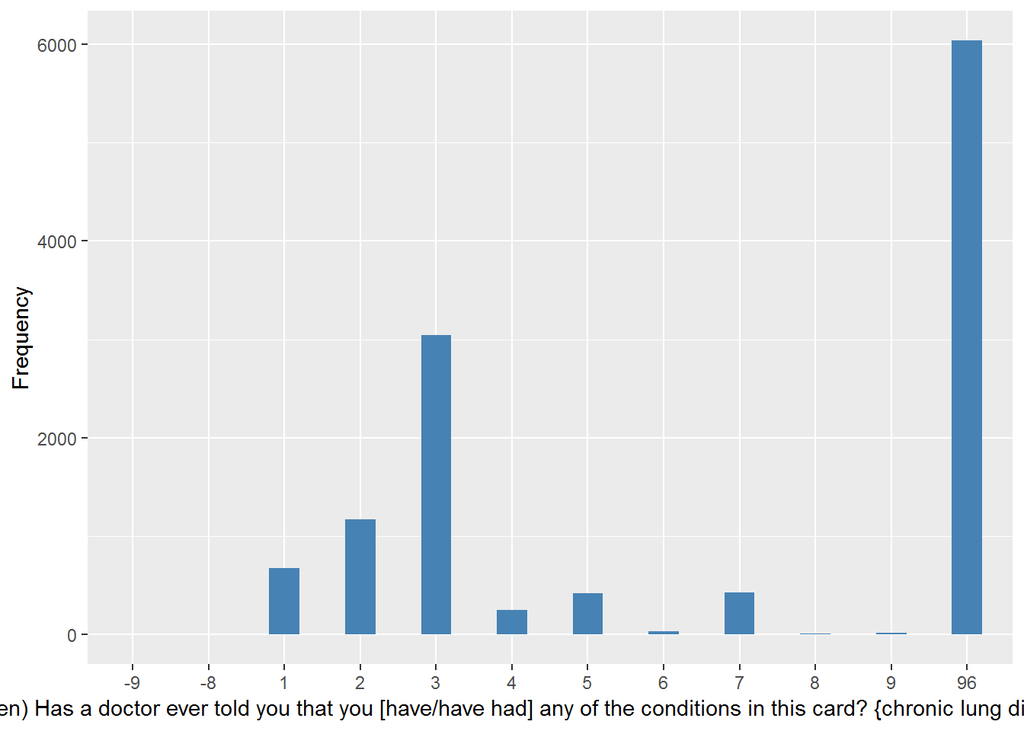

hedib02

| Sample size | Missing values |
| --- | --- |
| 12099 | 10312 |

Category

|  | 1 | 2 | 3 | 4 | 5 | 6 | 7 | 8 | 9 |
| --- | --- | --- | --- | --- | --- | --- | --- | --- | --- |
| Frequency | 72.0 | 239.00 | 641.0 | 237.00 | 231.00 | 18.00 | 319.00 | 2.00 | 28.00 |
| Percentage | 0.6 | 1.98 | 5.3 | 1.96 | 1.91 | 0.15 | 2.64 | 0.02 | 0.23 |

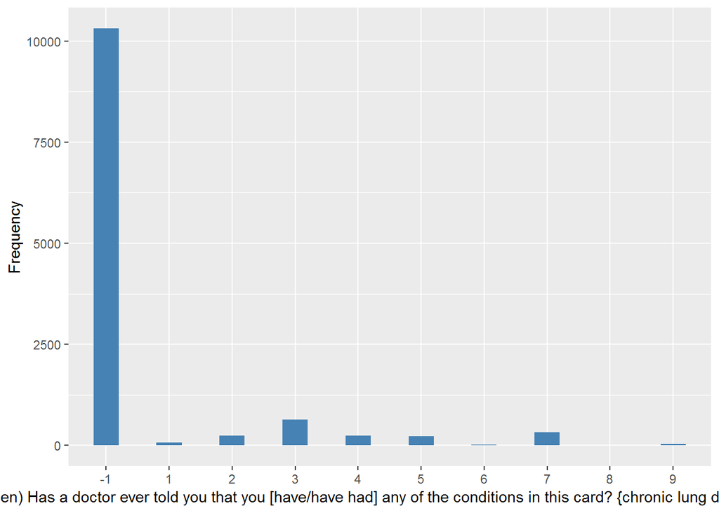

hedib03

| Sample size | Missing values |
| --- | --- |
| 12099 | 11687 |

Category

|  | 1 | 2 | 3 | 4 | 5 | 6 | 7 | 8 | 9 |
| --- | --- | --- | --- | --- | --- | --- | --- | --- | --- |
| Frequency | 10.00 | 4.00 | 126.00 | 70.00 | 62.00 | 4.00 | 122.00 | 2.00 | 12.0 |
| Percentage | 0.08 | 0.03 | 1.04 | 0.58 | 0.51 | 0.03 | 1.01 | 0.02 | 0.1 |

[figure not shown]

hedib04

| Sample size | Missing values |
| --- | --- |
| 12099 | 12028 |

Category

|  | 1 | 2 | 3 | 4 | 5 | 6 | 7 | 9 |
| --- | --- | --- | --- | --- | --- | --- | --- | --- |
| Frequency | 1.00 | 1.00 | 1.00 | 18.00 | 11.00 | 1.00 | 35.00 | 3.00 |
| Percentage | 0.01 | 0.01 | 0.01 | 0.15 | 0.09 | 0.01 | 0.29 | 0.02 |

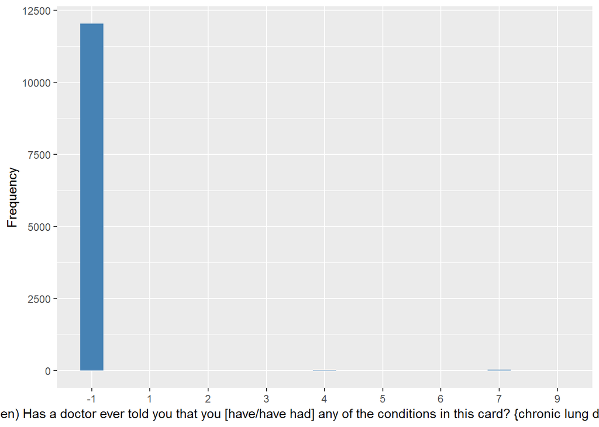

hedib05

| Sample size | Missing values |
| --- | --- |
| 12099 | 12089 |

Category

|  | 2 | 5 | 7 |
| --- | --- | --- | --- |
| Frequency | 1.00 | 2.00 | 7.00 |
| Percentage | 0.01 | 0.02 | 0.06 |

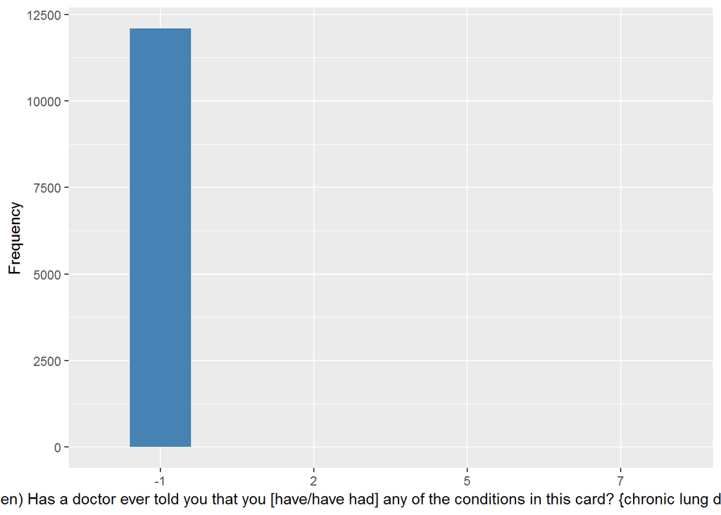

hedib06

| Sample size | Missing values |
| --- | --- |
| 12099 | 12098 |

Category

|  | 8 |
| --- | --- |
| Frequency | 1.00 |
| Percentage | 0.01 |

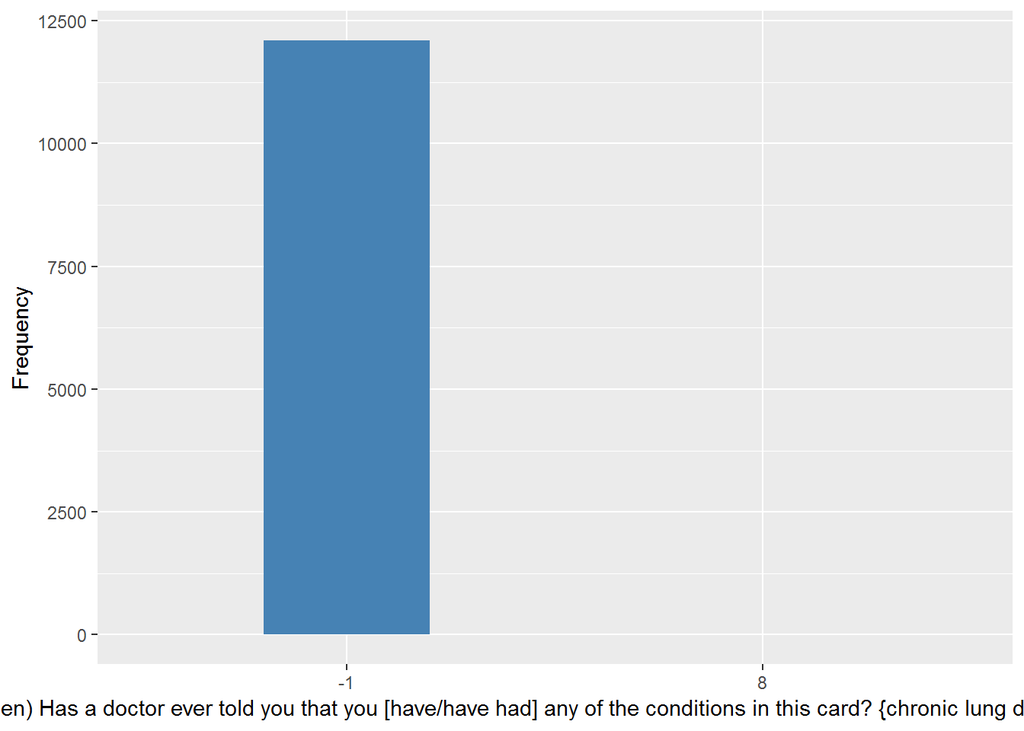

hedib07

| Sample size | Missing values |
| --- | --- |
| 12099 | 12099 |

hedib08

| Sample size | Missing values |
| --- | --- |
| 12099 | 12099 |

hedib09

| Sample size | Missing values |
| --- | --- |
| 12099 | 12099 |

hedib10

| Sample size | Missing values |
| --- | --- |
| 12099 | 12099 |

heagf

| Sample size | Missing values |
| --- | --- |
| 12099 | 8364 |

Summary

| Min. | 1st Qu. | Median | Mean | 3rd Qu. | Max. |
| --- | --- | --- | --- | --- | --- |
| 0 | 45 | 54 | 53.83 | 63 | 92 |

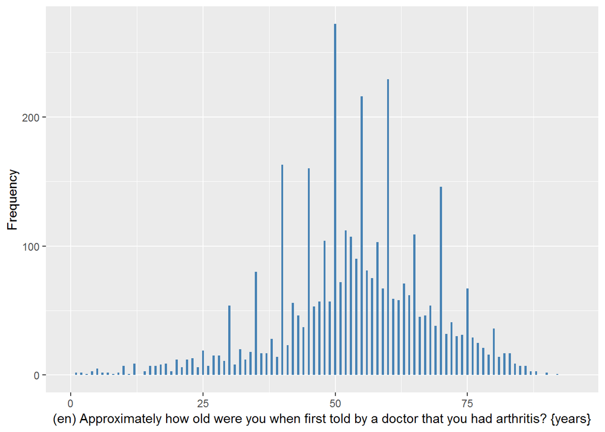

#### 2.1.1.2 Harmonisation algorithm

To compute `h_joint_disorders` from the study-specific variable it has to be recoded as follows:

- `some hedibX == 3 into 1`
- `-9 into 997`
- `-8 into 998`
- `otherwise into 0`

To compute `h_joint_disorders_age` from the study-specific variable it has to be recoded as follows:

- `if h_joint_disorders == 1, h_joint_disorders_age = heagf`
- `if h_joint_disorders == 0, h_joint_disorders_age = 996`
- `-9 into 997`
- `-8 into 998`
- `otherwise, h_joint_disorders_age = 999`

**R script:**

```r
# Categorical variable harmonization
ELSA_ds_w1 <- tibble(id = ELSA_w1$id)
ELSA_ds_w1$h_joint_disorders <- rep(0, length(ELSA_w1$id))
ELSA_ds_w1$h_joint_disorders[which((ELSA_w1$hedib01 == 3 | ELSA_w1$hedib02 ==
    3 | ELSA_w1$hedib03 == 3 | ELSA_w1$hedib04 == 3 | ELSA_w1$hedib05 == 3 |
    ELSA_w1$hedib06 == 3 | ELSA_w1$hedib07 == 3 | ELSA_w1$hedib08 == 3 | ELSA_w1$hedib09 ==
    3 | ELSA_w1$hedib10 == 3))] <- 1
ELSA_ds_w1$h_joint_disorders[which(ELSA_w1$hedib01 == -9)] <- 997
ELSA_ds_w1$h_joint_disorders[which(ELSA_w1$hedib01 == -8)] <- 998

# Continuous variable harmonization
ELSA_ds_w1$h_joint_disorders_age <- rep(999, length(ELSA_w1$id))
ELSA_ds_w1$h_joint_disorders_age[which(ELSA_ds_w1$h_joint_disorders == 0)] <- 996
ELSA_ds_w1$h_joint_disorders_age[which(ELSA_ds_w1$h_joint_disorders == 1)] <- car::recode(ELSA_w1$heagf[which(ELSA_ds_w1$h_joint_disorders ==
    1)], "-1=996;-8=998;-9=997")

# Global table
ELSA_ds <- ELSA_ds_w1
```

#### 2.1.1.3 Statistics of the new harmonized variable

History of arthritis, rheumatism or osteoarthritis

| Sample size | Missing values |
| --- | --- |
| 12099 | 10 |

Category

|  | 0 | 1 |
| --- | --- | --- |
| Frequency | 8279.00 | 3810.00 |
| Percentage | 68.43 | 31.49 |

Type of missing

|  | 991 | 992 | 993 | 994 | 995 | 996 | 997 | 998 | 999 | NA |
| --- | --- | --- | --- | --- | --- | --- | --- | --- | --- | --- |
| Frequency | 0 | 0 | 0 | 0 | 0 | 0 | 4.00 | 6.00 | 0 | 0 |
| Percentage | 0 | 0 | 0 | 0 | 0 | 0 | 0.03 | 0.05 | 0 | 0 |

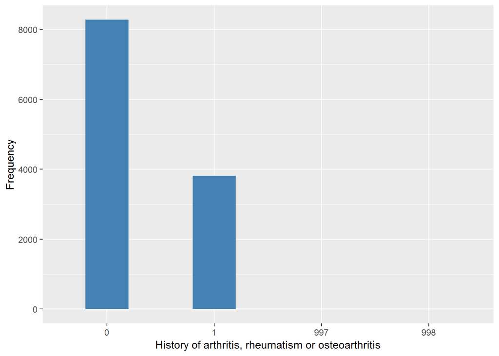

Age first diagnosed joint disorder

| Sample size | Missing values |
| --- | --- |
| 12099 | 8364 |

Values

|  | No-missings | 991 | 992 | 993 | 994 | 995 | 996 | 997 | 998 | 999 | NA |
| --- | --- | --- | --- | --- | --- | --- | --- | --- | --- | --- | --- |
| Frequency | 3735.00 | 0 | 0 | 0 | 0 | 0 | 8279.00 | 0 | 75.00 | 10.00 | 0 |
| Percentage | 30.87 | 0 | 0 | 0 | 0 | 0 | 68.43 | 0 | 0.62 | 0.08 | 0 |

Summary

| Min. | 1st Qu. | Median | Mean | 3rd Qu. | Max. |
| --- | --- | --- | --- | --- | --- |
| 0 | 45 | 54 | 53.83 | 63 | 92 |

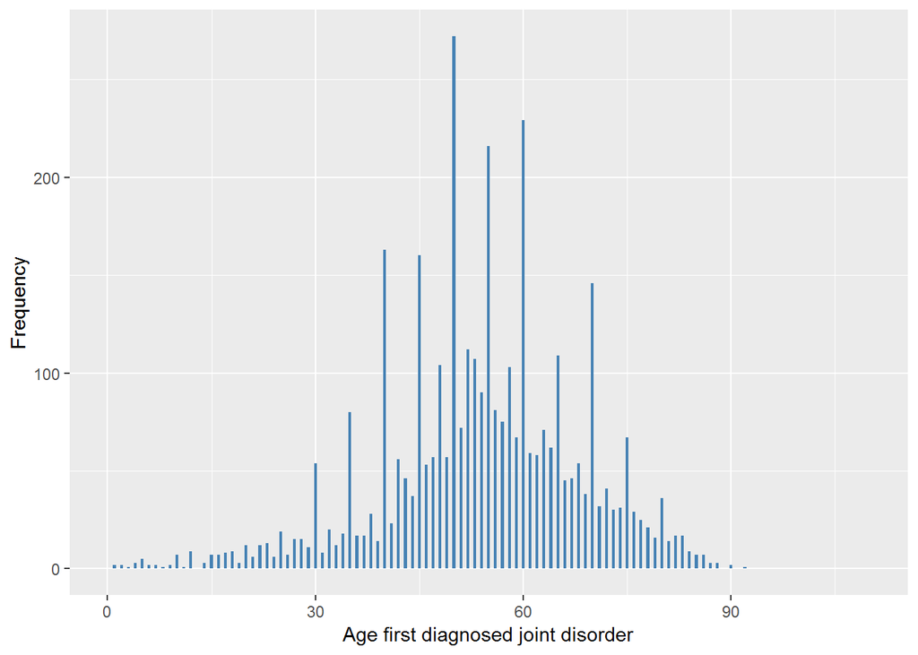

#### 2.1.1.4 Validation

|  | hedibX!=3->0 | hedibX==3->1 | hedibX==-9->997 | hedibX==-8->998 |
| --- | --- | --- | --- | --- |
| BeforeH | 8279 | 3810 | 4 | 6 |
| AfterH | 8279 | 3810 | 4 | 6 |

### 2.1.2 Wave 2

#### 2.1.2.1 Study-specific variable description

| **Name** | `hedib01` | `hedib02` | `hedib03` | `hedib04` | `HeAgf` |  |
| --- | --- | --- | --- | --- | --- | --- |
| **Label** | `Diagnosed chronic condition newly reported at W2 (1st mention)` | `Diagnosed chronic condition newly reported at W2 (2nd mention)` | `Diagnosed chronic condition newly reported at W2 (3rd mention)` | `Diagnosed chronic condition newly reported at W2 (4th mention)` | `Age first told had arthritis` |  |
| **Table name** | `wave_2_core_data_v4` | `wave_2_core_data_v4` | `wave_2_core_data_v4` | `wave_2_core_data_v4` | `wave_2_core_data_v4` |  |
| **Categories** | `1 = Chronic lung disease such as chronic bronchitis or emphysema` `2 = Asthma` `3 = Arthritis (including osteoarthritis , or rheumatism)` `4 = Osteoporosis, sometimes called thin or brittle bones` `5… | `1 = Chronic lung disease such as chronic bronchitis or emphysema` `2 = Asthma` `3 = Arthritis (including osteoarthritis , or rheumatism)` `4 = Osteoporosis, sometimes called thin or brittle bones` `5… | `1 = Chronic lung disease such as chronic bronchitis or emphysema` `2 = Asthma` `3 = Arthritis (including osteoarthritis , or rheumatism)` `4 = Osteoporosis, sometimes called thin or brittle bones` `5… | `1 = Chronic lung disease such as chronic bronchitis or emphysema` `2 = Asthma` `3 = Arthritis (including osteoarthritis , or rheumatism)` `4 = Osteoporosis, sometimes called thin or brittle bones` `5… | `continuous` |  |
| **Missings** | `-9 = Refusal` `-8 = Don't know` `-1 = Not applicable` | `-9 = Refusal` `-8 = Don't know` `-1 = Not applicable` | `-9 = Refusal` `-8 = Don't know` `-1 = Not applicable` | `-9 = Refusal` `-8 = Don't know` `-1 = Not applicable` | `-1 = Not applicable` |  |
| **Description** |  |  |  |  |  |  |

hedib01

| Sample size | Missing values |
| --- | --- |
| 9432 | 6 |

Category

|  | 1 | 2 | 3 | 4 | 5 | 6 | 7 | 8 | 9 | 96 |
| --- | --- | --- | --- | --- | --- | --- | --- | --- | --- | --- |
| Frequency | 143.00 | 128.00 | 574.00 | 183.00 | 175.00 | 18.00 | 193.00 | 11.00 | 33.00 | 7968.00 |
| Percentage | 1.52 | 1.36 | 6.09 | 1.94 | 1.86 | 0.19 | 2.05 | 0.12 | 0.35 | 84.48 |

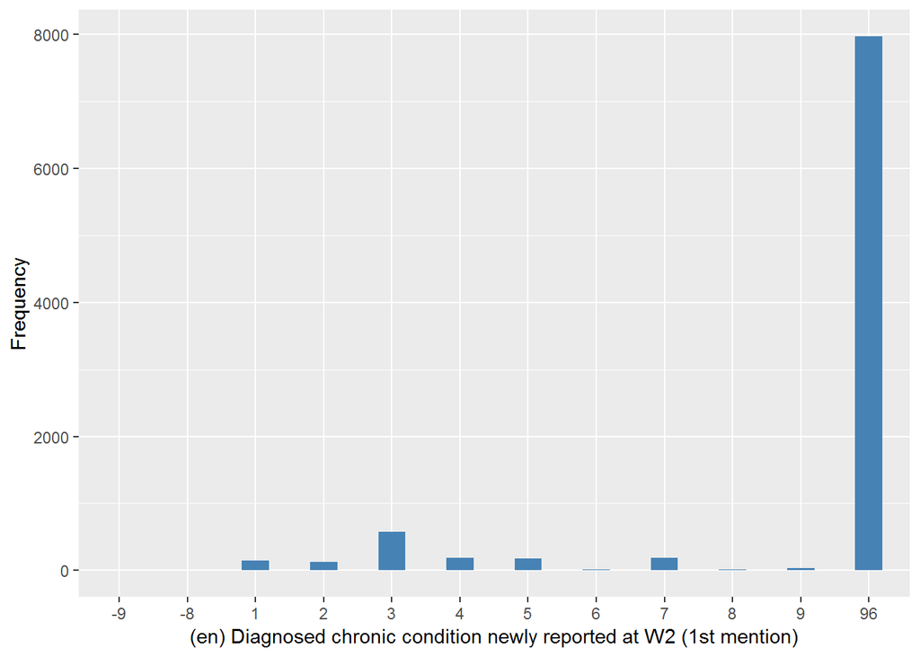

hedib02

| Sample size | Missing values |
| --- | --- |
| 9432 | 9310 |

Category

|  | 1 | 2 | 3 | 4 | 5 | 7 | 9 |
| --- | --- | --- | --- | --- | --- | --- | --- |
| Frequency | 4.00 | 11.00 | 19.0 | 19.0 | 27.00 | 35.00 | 7.00 |
| Percentage | 0.04 | 0.12 | 0.2 | 0.2 | 0.29 | 0.37 | 0.07 |

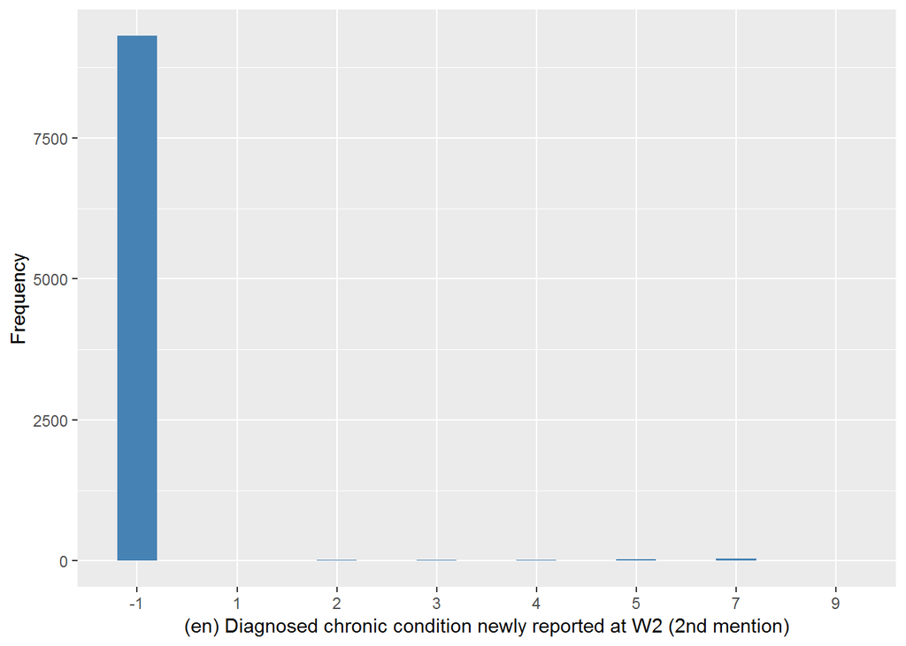

hedib03

| Sample size | Missing values |
| --- | --- |
| 9432 | 9419 |

Category

|  | 3 | 4 | 5 | 7 | 9 |
| --- | --- | --- | --- | --- | --- |
| Frequency | 3.00 | 2.00 | 2.00 | 3.00 | 3.00 |
| Percentage | 0.03 | 0.02 | 0.02 | 0.03 | 0.03 |

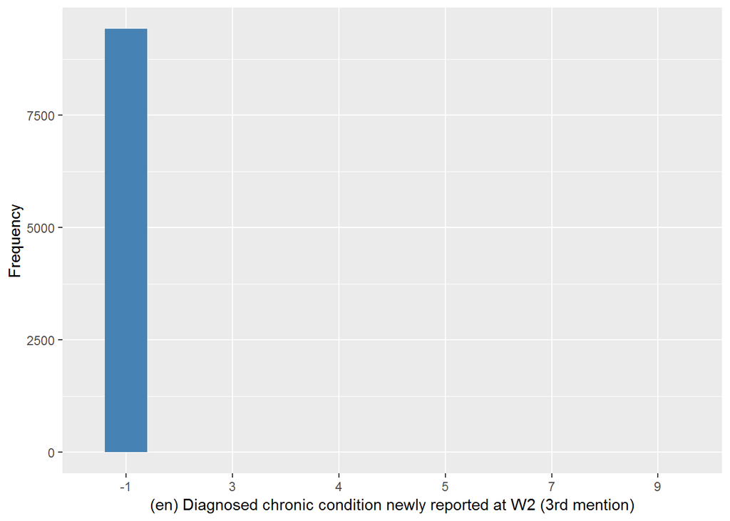

hedib04

| Sample size | Missing values |
| --- | --- |
| 9432 | 9428 |

Category

|  | 7 |
| --- | --- |
| Frequency | 4.00 |
| Percentage | 0.04 |

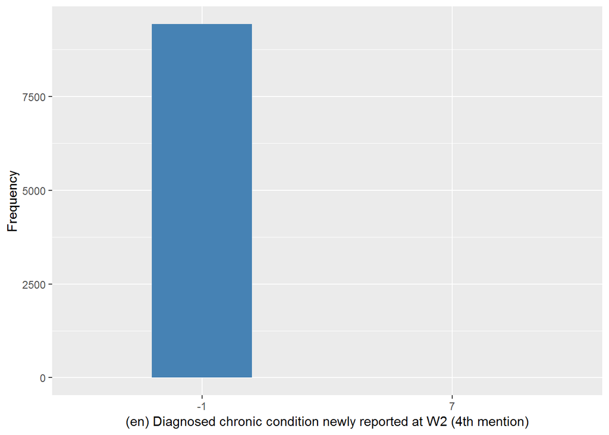

HeAgf

| Sample size | Missing values |
| --- | --- |
| 9432 | 9410 |

Summary

| Min. | 1st Qu. | Median | Mean | 3rd Qu. | Max. |
| --- | --- | --- | --- | --- | --- |
| 20 | 47.75 | 54.5 | 52.41 | 59.5 | 74 |

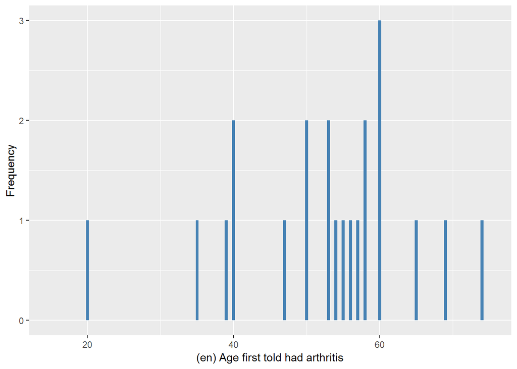

#### 2.1.2.2 Harmonisation algorithm

To compute `h_joint_disorders` from the study-specific variable it has to be recoded as follows:

- `h_joint_disorders w1 == 1 or some hedibX == 3 into 1`
- `h_joint_disorders w1 != 1 and hedib01 == -9 into 997`
- `h_joint_disorders w1 != 1 and hedib01 == -8 into 998`
- `otherwise into 0`

To compute `h_joint_disorders_age` from the study-specific variable it has to be recoded as follows:

- `if h_joint_disorders == 1, h_joint_disorders_age = HeAgf`
- `if h_joint_disorders == 0, h_joint_disorders_age = 996`
- `-9 into 997`
- `-8 into 998`
- `otherwise, h_joint_disorders_age = 999`

**R script:**

```r
ELSA_w2 <- left_join(ELSA_w2, ELSA_ds, by = "id")

# Categorical variable harmonization
ELSA_ds_w2 <- tibble(id = ELSA_w2$id)
ELSA_ds_w2$h_joint_disorders <- rep(0, length(ELSA_w2$id))
ELSA_ds_w2$h_joint_disorders[which(ELSA_w2$h_joint_disorders == 1 | ((ELSA_w2$hedib01 ==
    3 | ELSA_w2$hedib02 == 3 | ELSA_w2$hedib03 == 3 | ELSA_w2$hedib04 == 3)))] <- 1
ELSA_ds_w2$h_joint_disorders[which((ELSA_w2$h_joint_disorders != 1 | is.na(ELSA_w2$h_joint_disorders)) &
    ELSA_w2$hedib01 == -9)] <- 997
ELSA_ds_w2$h_joint_disorders[which((ELSA_w2$h_joint_disorders != 1 | is.na(ELSA_w2$h_joint_disorders)) &
    ELSA_w2$hedib01 == -8)] <- 998

# Continuous variable harmonization
ELSA_ds_w2$h_joint_disorders_age <- rep(999, length(ELSA_w2$id))
ELSA_ds_w2$h_joint_disorders_age[which(ELSA_ds_w2$h_joint_disorders == 0)] <- 996
ELSA_ds_w2$h_joint_disorders_age[which(ELSA_ds_w2$h_joint_disorders == 1)] <- car::recode(ELSA_w2$HeAgf[which(ELSA_ds_w2$h_joint_disorders ==
    1)], "-1=996;-8=998;-9=997")
ELSA_ds_w2$h_joint_disorders_age[which(ELSA_ds_w2$h_joint_disorders == 1 & !is.na(ELSA_w2$h_joint_disorders_age) &
    !ELSA_w2$h_joint_disorders_age %in% miss_values_vector)] <- ELSA_w2$h_joint_disorders_age[which(ELSA_ds_w2$h_joint_disorders ==
    1 & !is.na(ELSA_w2$h_joint_disorders_age) & !ELSA_w2$h_joint_disorders_age %in%
    miss_values_vector)]

# Update of global table
assign_merge <- function(endtib, sttib, log_vec = c(T), col_end_index = NULL,
    col_st_index = NULL) {
    newtib <- full_join(endtib, sttib, by = "id")
    row.names(newtib) <- newtib$id
    newtib[log_vec, col_end_index] <- newtib[log_vec, col_st_index]
    id_ind <- match("id", names(newtib))
    newtib <- newtib[, c(id_ind, col_end_index)]
    names(newtib)[2] <- "x"
    newtib$x <- car::recode(newtib$x, "NA=999")
    names(newtib)[2] <- names(endtib)[col_end_index]
    newtib
}
ELSA_ds_prov <- ELSA_ds[, c(1, 2)]
ELSA_ds_prov <- assign_merge(ELSA_ds_prov, ELSA_ds_w2, log_vec = ELSA_ds_w2$id,
    col_end_index = 2, col_st_index = 3)
ELSA_ds_aux <- ELSA_ds[, c(1, 3)]
ELSA_ds_aux <- assign_merge(ELSA_ds_aux, ELSA_ds_w2, log_vec = ELSA_ds_w2$id[which(ELSA_ds_w2$h_joint_disorders !=
    999)], col_end_index = 2, col_st_index = 4)
ELSA_ds <- ELSA_ds_prov
ELSA_ds$h_joint_disorders_age <- ELSA_ds_aux$h_joint_disorders_age
rm(ELSA_ds_prov)
rm(ELSA_ds_aux)
```

#### 2.1.2.3 Statistics of the new harmonized variable

History of arthritis, rheumatism or osteoarthritis

| Sample size | Missing values |
| --- | --- |
| 9432 | 2 |

Category

|  | 0 | 1 |
| --- | --- | --- |
| Frequency | 5945.00 | 3485.00 |
| Percentage | 63.03 | 36.95 |

Type of missing

|  | 991 | 992 | 993 | 994 | 995 | 996 | 997 | 998 | 999 | NA |
| --- | --- | --- | --- | --- | --- | --- | --- | --- | --- | --- |
| Frequency | 0 | 0 | 0 | 0 | 0 | 0 | 1.00 | 1.00 | 0 | 0 |
| Percentage | 0 | 0 | 0 | 0 | 0 | 0 | 0.01 | 0.01 | 0 | 0 |

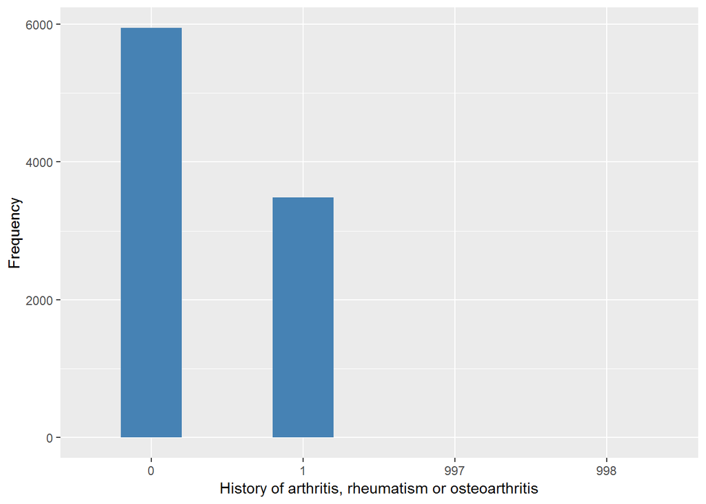

Age first diagnosed joint disorder

| Sample size | Missing values |
| --- | --- |
| 9432 | 6530 |

Values

|  | No-missings | 991 | 992 | 993 | 994 | 995 | 996 | 997 | 998 | 999 | NA |
| --- | --- | --- | --- | --- | --- | --- | --- | --- | --- | --- | --- |
| Frequency | 2902.00 | 0 | 0 | 0 | 0 | 0 | 6528.00 | 0 | 0 | 2.00 | 0 |
| Percentage | 30.77 | 0 | 0 | 0 | 0 | 0 | 69.21 | 0 | 0 | 0.02 | 0 |

Summary

| Min. | 1st Qu. | Median | Mean | 3rd Qu. | Max. |
| --- | --- | --- | --- | --- | --- |
| 0 | 45 | 54 | 53.53 | 62 | 92 |

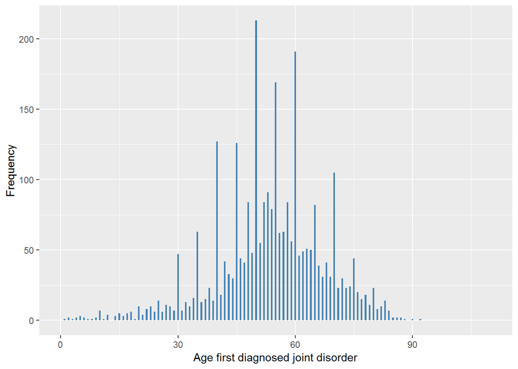

#### 2.1.2.4 Validation

|  | hedibX!=3->0 | hedibX==3->1 | hedibX==-9->997 | hedibX==-8->998 |
| --- | --- | --- | --- | --- |
| BeforeH | 5945 | 3485 | 1 | 1 |
| AfterH | 5945 | 3485 | 1 | 1 |

### 2.1.3 Wave 3

#### 2.1.3.1 Study-specific variable description

| **Name** | `dhedibar` | `heagf` |
| --- | --- | --- |
| **Label** | `Chronic: arthritis diagnosis newly reported` | `Age first told had arthritis` |
| **Table name** | `wave_3_elsa_data_v4` | `wave_3_elsa_data_v4` |
| **Categories** | `1 = Mentioned` `0 = Not mentioned` | `continuous` |
| **Missings** | `-9 = Refusal` `-8 = Don't know` `-1 = Not applicable` | `-8 = Don't know` `-1 = Not applicable` |
| **Description** |  |  |

dhedibar

| Sample size | Missing values |
| --- | --- |
| 9771 | 9 |

Category

|  | 0 | 1 |
| --- | --- | --- |
| Frequency | 9086.00 | 676.00 |
| Percentage | 92.99 | 6.92 |

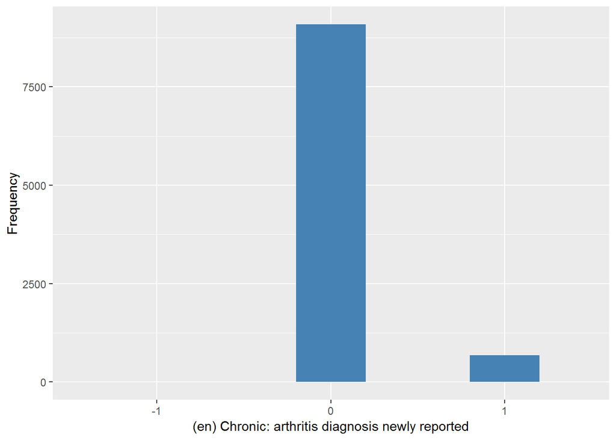

heagf

| Sample size | Missing values |
| --- | --- |
| 9771 | 9504 |

Summary

| Min. | 1st Qu. | Median | Mean | 3rd Qu. | Max. |
| --- | --- | --- | --- | --- | --- |
| 3 | 38 | 45 | 43.61 | 50 | 84 |

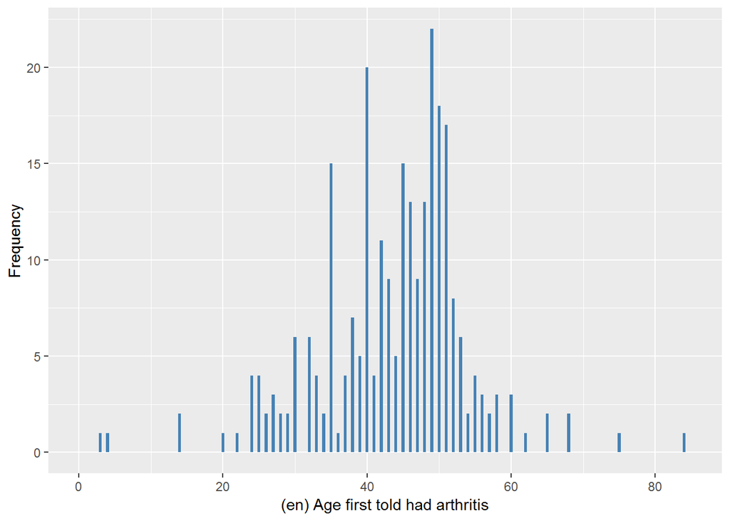

#### 2.1.3.2 Harmonisation algorithm

To compute `h_joint_disorders` from the study-specific variable it has to be recoded as follows:

- `h_joint_disorders previous == 1 or dhedibar == 1 into 1`
- `h_joint_disorders previous == 0 and dhedibar == 0 into 0`
- `dhedibar == -1 into 996`
- `otherwise into 999`

To compute `h_joint_disorders_age` from the study-specific variable it has to be recoded as follows:

- `if h_joint_disorders == 1, h_joint_disorders_age = heagf`
- `if h_joint_disorders == 0, h_joint_disorders_age = 996`
- `-9 into 997`
- `-8 into 998`
- `otherwise, h_joint_disorders_age = 999`

**R script:**

```r
ELSA_w3 <- left_join(ELSA_w3, ELSA_ds, by = "id")

# Categorical variable harmonization
ELSA_ds_w3 <- tibble(id = ELSA_w3$id)
ELSA_ds_w3$h_joint_disorders <- rep(999, length(ELSA_w3$id))
ELSA_ds_w3$h_joint_disorders[which((ELSA_w3$h_joint_disorders != 1 | is.na(ELSA_w3$h_joint_disorders)) &
    (ELSA_w3$dhedibar == 0))] <- 0
ELSA_ds_w3$h_joint_disorders[which(ELSA_w3$h_joint_disorders == 1 | (ELSA_w3$dhedibar ==
    1))] <- 1
ELSA_ds_w3$h_joint_disorders[which((ELSA_w3$h_joint_disorders != 1 | is.na(ELSA_w3$h_joint_disorders)) &
    (ELSA_w3$dhedibar == -1))] <- 996

# Continuous variable harmonization
ELSA_ds_w3$h_joint_disorders_age <- rep(999, length(ELSA_w3$id))
ELSA_ds_w3$h_joint_disorders_age[which(ELSA_ds_w3$h_joint_disorders == 0)] <- 996
ELSA_ds_w3$h_joint_disorders_age[which(ELSA_ds_w3$h_joint_disorders == 1)] <- car::recode(ELSA_w3$heagf[which(ELSA_ds_w3$h_joint_disorders ==
    1)], "-1=996;-8=998;-9=997")
ELSA_ds_w3$h_joint_disorders_age[which(ELSA_ds_w3$h_joint_disorders == 1 & !is.na(ELSA_w3$h_joint_disorders_age) &
    !ELSA_w3$h_joint_disorders_age %in% miss_values_vector)] <- ELSA_w3$h_joint_disorders_age[which(ELSA_ds_w3$h_joint_disorders ==
    1 & !is.na(ELSA_w3$h_joint_disorders_age) & !ELSA_w3$h_joint_disorders_age %in%
    miss_values_vector)]

# Update of global table
assign_merge <- function(endtib, sttib, log_vec = c(T), col_end_index = NULL,
    col_st_index = NULL) {
    newtib <- full_join(endtib, sttib, by = "id")
    row.names(newtib) <- newtib$id
    newtib[log_vec, col_end_index] <- newtib[log_vec, col_st_index]
    id_ind <- match("id", names(newtib))
    newtib <- newtib[, c(id_ind, col_end_index)]
    names(newtib)[2] <- "x"
    newtib$x <- car::recode(newtib$x, "NA=999")
    names(newtib)[2] <- names(endtib)[col_end_index]
    newtib
}
ELSA_ds_prov <- ELSA_ds[, c(1, 2)]
ELSA_ds_prov <- assign_merge(ELSA_ds_prov, ELSA_ds_w3, log_vec = ELSA_ds_w3$id,
    col_end_index = 2, col_st_index = 3)
ELSA_ds_aux <- ELSA_ds[, c(1, 3)]
ELSA_ds_aux <- assign_merge(ELSA_ds_aux, ELSA_ds_w3, log_vec = ELSA_ds_w3$id[which(ELSA_ds_w3$h_joint_disorders !=
    999)], col_end_index = 2, col_st_index = 4)
ELSA_ds <- ELSA_ds_prov
ELSA_ds$h_joint_disorders_age <- ELSA_ds_aux$h_joint_disorders_age
rm(ELSA_ds_prov)
rm(ELSA_ds_aux)
```

#### 2.1.3.3 Statistics of the new harmonized variable

History of arthritis, rheumatism or osteoarthritis

| Sample size | Missing values |
| --- | --- |
| 9771 | 8 |

Category

|  | 0 | 1 |
| --- | --- | --- |
| Frequency | 6187.00 | 3576.0 |
| Percentage | 63.32 | 36.6 |

Type of missing

|  | 991 | 992 | 993 | 994 | 995 | 996 | 997 | 998 | 999 | NA |
| --- | --- | --- | --- | --- | --- | --- | --- | --- | --- | --- |
| Frequency | 0 | 0 | 0 | 0 | 0 | 8.00 | 0 | 0 | 0 | 0 |
| Percentage | 0 | 0 | 0 | 0 | 0 | 0.08 | 0 | 0 | 0 | 0 |

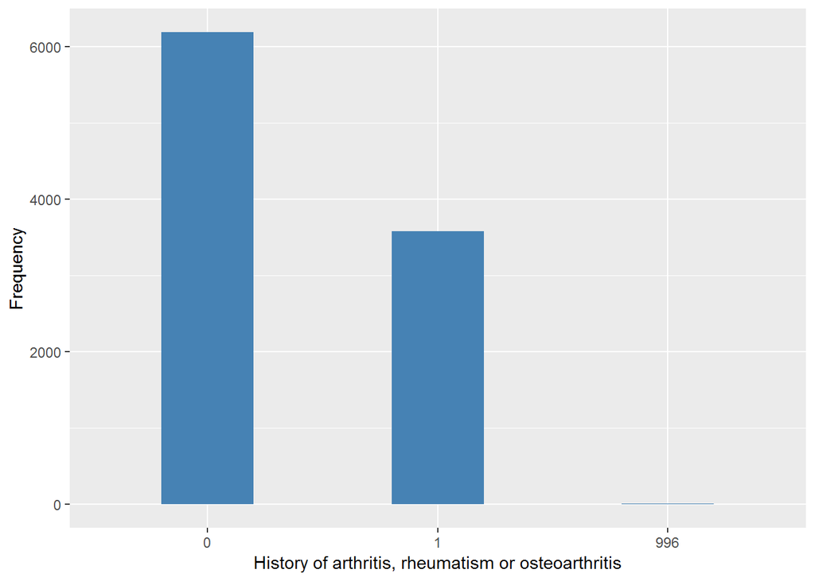

Age first diagnosed joint disorder

| Sample size | Missing values |
| --- | --- |
| 9771 | 7034 |

Values

|  | No-missings | 991 | 992 | 993 | 994 | 995 | 996 | 997 | 998 | 999 | NA |
| --- | --- | --- | --- | --- | --- | --- | --- | --- | --- | --- | --- |
| Frequency | 2737.00 | 0 | 0 | 0 | 0 | 0 | 7023.00 | 0 | 3.00 | 8.00 | 0 |
| Percentage | 28.01 | 0 | 0 | 0 | 0 | 0 | 71.88 | 0 | 0.03 | 0.08 | 0 |

Summary

| Min. | 1st Qu. | Median | Mean | 3rd Qu. | Max. |
| --- | --- | --- | --- | --- | --- |
| 0 | 45 | 53 | 52.29 | 60 | 92 |

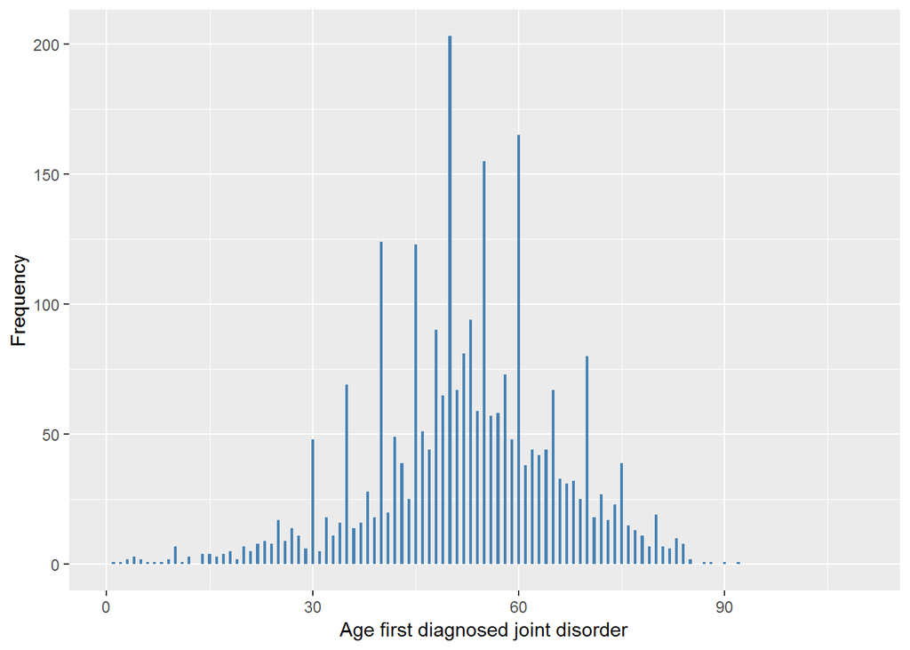

#### 2.1.3.4 Validation

|  | dhedibar==0->0 | dhedibar==1->1 | dhedibar==-1->996 |
| --- | --- | --- | --- |
| BeforeH | 6187 | 3576 | 8 |
| AfterH | 6187 | 3576 | 8 |

### 2.1.4 Wave 4

#### 2.1.4.1 Study-specific variable description

| **Name** | `hedibar` | `heagf` |  |
| --- | --- | --- | --- |
| **Label** | `Chronic: arthritis diagnosis newly reported` | `Age first told had arthritis` |  |
| **Table name** | `wave_4_elsa_data_v3` | `wave_4_elsa_data_v3` |  |
| **Categories** | `1 = Mentioned` `0 = Not mentioned` | `continuous` |  |
| **Missings** | `-9 = Refusal` `-8 = Don't know` `-1 = Not applicable` | `-9 = Refusal` `-8 = Don't know` `-2 = Capi/Interview Error` `-1 = Not applicable` |  |
| **Description** |  |  |  |

hedibar

| Sample size | Missing values |
| --- | --- |
| 11050 | 25 |

Category

|  | 0 | 1 |
| --- | --- | --- |
| Frequency | 9834 | 1191.00 |
| Percentage | 89 | 10.78 |

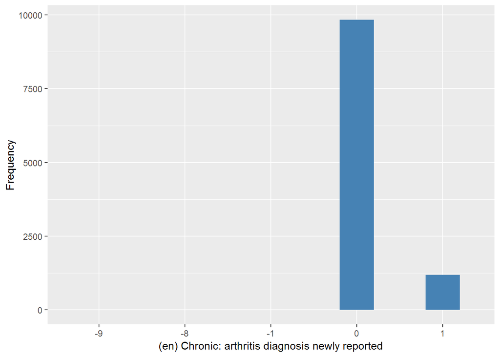

heagf

| Sample size | Missing values |
| --- | --- |
| 11050 | 10311 |

Summary

[output not shown]

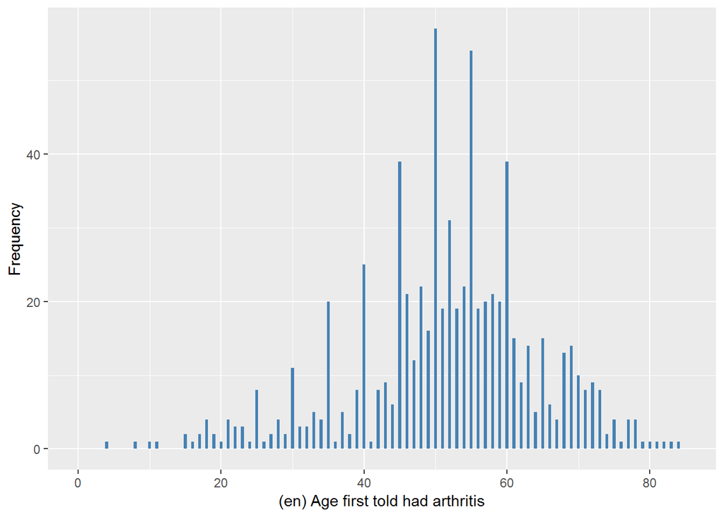

#### 2.1.4.2 Harmonisation algorithm

To compute `h_joint_disorders` from the study-specific variable it has to be recoded as follows:

- `h_joint_disorders previous == 1 or hedibar == 1 into 1`
- `h_joint_disorders previous == 0 and hedibar == 0 into 0`
- `hedibar == -1 into 996`
- `hedibar == -9 into 997`
- `hedibar == -8 into 998`
- `otherwise into 999`

To compute `h_joint_disorders_age` from the study-specific variable it has to be recoded as follows:

- `if h_joint_disorders == 1, h_joint_disorders_age = heagf`
- `if h_joint_disorders == 0, h_joint_disorders_age = 996`
- `-9 into 997`
- `-8 into 998`
- `-2 into 991`
- `-1 into 996`
- `otherwise, h_joint_disorders_age = 999`

**R script:**

```r
ELSA_w4 <- left_join(ELSA_w4, ELSA_ds, by = "id")

# Categorical variable harmonization
ELSA_ds_w4 <- tibble(id = ELSA_w4$id)
ELSA_ds_w4$h_joint_disorders <- rep(999, length(ELSA_w4$id))
ELSA_ds_w4$h_joint_disorders[which((ELSA_w4$h_joint_disorders != 1 | is.na(ELSA_w4$h_joint_disorders)) &
    (ELSA_w4$hedibar == 0))] <- 0
ELSA_ds_w4$h_joint_disorders[which(ELSA_w4$h_joint_disorders == 1 | (ELSA_w4$hedibar ==
    1))] <- 1
ELSA_ds_w4$h_joint_disorders[which((ELSA_w4$h_joint_disorders != 1 | is.na(ELSA_w4$h_joint_disorders)) &
    ELSA_w4$hedibar == -1)] <- 996
ELSA_ds_w4$h_joint_disorders[which((ELSA_w4$h_joint_disorders != 1 | is.na(ELSA_w4$h_joint_disorders)) &
    ELSA_w4$hedibar == -9)] <- 997
ELSA_ds_w4$h_joint_disorders[which((ELSA_w4$h_joint_disorders != 1 | is.na(ELSA_w4$h_joint_disorders)) &
    ELSA_w4$hedibar == -8)] <- 998


# Continuous variable harmonization
ELSA_ds_w4$h_joint_disorders_age <- rep(999, length(ELSA_w4$id))
ELSA_ds_w4$h_joint_disorders_age[which(ELSA_ds_w4$h_joint_disorders == 0)] <- 996
ELSA_ds_w4$h_joint_disorders_age[which(ELSA_ds_w4$h_joint_disorders == 1)] <- car::recode(ELSA_w4$heagf[which(ELSA_ds_w4$h_joint_disorders ==
    1)], "-1=996;-2=991;-8=998;-9=997")
ELSA_ds_w4$h_joint_disorders_age[which(ELSA_ds_w4$h_joint_disorders == 1 & !is.na(ELSA_w4$h_joint_disorders_age) &
    !ELSA_w4$h_joint_disorders_age %in% miss_values_vector)] <- ELSA_w4$h_joint_disorders_age[which(ELSA_ds_w4$h_joint_disorders ==
    1 & !is.na(ELSA_w4$h_joint_disorders_age) & !ELSA_w4$h_joint_disorders_age %in%
    miss_values_vector)]

# Update of global table
assign_merge <- function(endtib, sttib, log_vec = c(T), col_end_index = NULL,
    col_st_index = NULL) {
    newtib <- full_join(endtib, sttib, by = "id")
    row.names(newtib) <- newtib$id
    newtib[log_vec, col_end_index] <- newtib[log_vec, col_st_index]
    id_ind <- match("id", names(newtib))
    newtib <- newtib[, c(id_ind, col_end_index)]
    names(newtib)[2] <- "x"
    newtib$x <- car::recode(newtib$x, "NA=999")
    names(newtib)[2] <- names(endtib)[col_end_index]
    newtib
}
ELSA_ds_prov <- ELSA_ds[, c(1, 2)]
ELSA_ds_prov <- assign_merge(ELSA_ds_prov, ELSA_ds_w4, log_vec = ELSA_ds_w4$id,
    col_end_index = 2, col_st_index = 3)
ELSA_ds_aux <- ELSA_ds[, c(1, 3)]
ELSA_ds_aux <- assign_merge(ELSA_ds_aux, ELSA_ds_w4, log_vec = ELSA_ds_w4$id[which(ELSA_ds_w4$h_joint_disorders !=
    999)], col_end_index = 2, col_st_index = 4)
ELSA_ds <- ELSA_ds_prov
ELSA_ds$h_joint_disorders_age <- ELSA_ds_aux$h_joint_disorders_age
rm(ELSA_ds_prov)
rm(ELSA_ds_aux)
```

#### 2.1.4.3 Statistics of the new harmonized variable

History of arthritis, rheumatism or osteoarthritis

| Sample size | Missing values |
| --- | --- |
| 11050 | 13 |

Category

|  | 0 | 1 |
| --- | --- | --- |
| Frequency | 6941.00 | 4096.00 |
| Percentage | 62.81 | 37.07 |

Type of missing

|  | 991 | 992 | 993 | 994 | 995 | 996 | 997 | 998 | 999 | NA |
| --- | --- | --- | --- | --- | --- | --- | --- | --- | --- | --- |
| Frequency | 0 | 0 | 0 | 0 | 0 | 0 | 5.00 | 8.00 | 0 | 0 |
| Percentage | 0 | 0 | 0 | 0 | 0 | 0 | 0.05 | 0.07 | 0 | 0 |

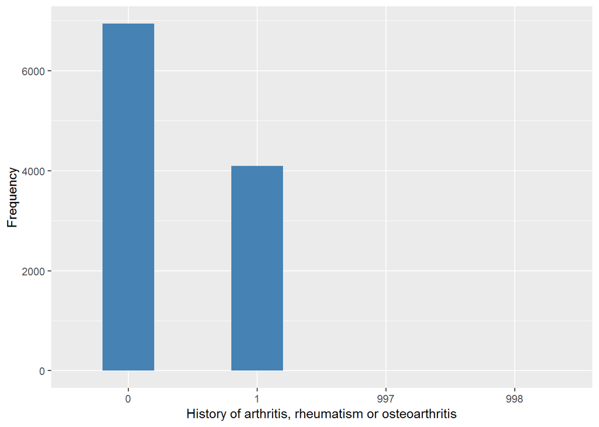

Age first diagnosed joint disorder

| Sample size | Missing values |
| --- | --- |
| 11050 | 8024 |

Values

|  | No-missings | 991 | 992 | 993 | 994 | 995 | 996 | 997 | 998 | 999 | NA |
| --- | --- | --- | --- | --- | --- | --- | --- | --- | --- | --- | --- |
| Frequency | 3026.00 | 7.00 | 0 | 0 | 0 | 0 | 7987.00 | 0 | 17.00 | 13.00 | 0 |
| Percentage | 27.38 | 0.06 | 0 | 0 | 0 | 0 | 72.28 | 0 | 0.15 | 0.12 | 0 |

Summary

| Min. | 1st Qu. | Median | Mean | 3rd Qu. | Max. |
| --- | --- | --- | --- | --- | --- |
| 0 | 45 | 52 | 51.77 | 60 | 90 |

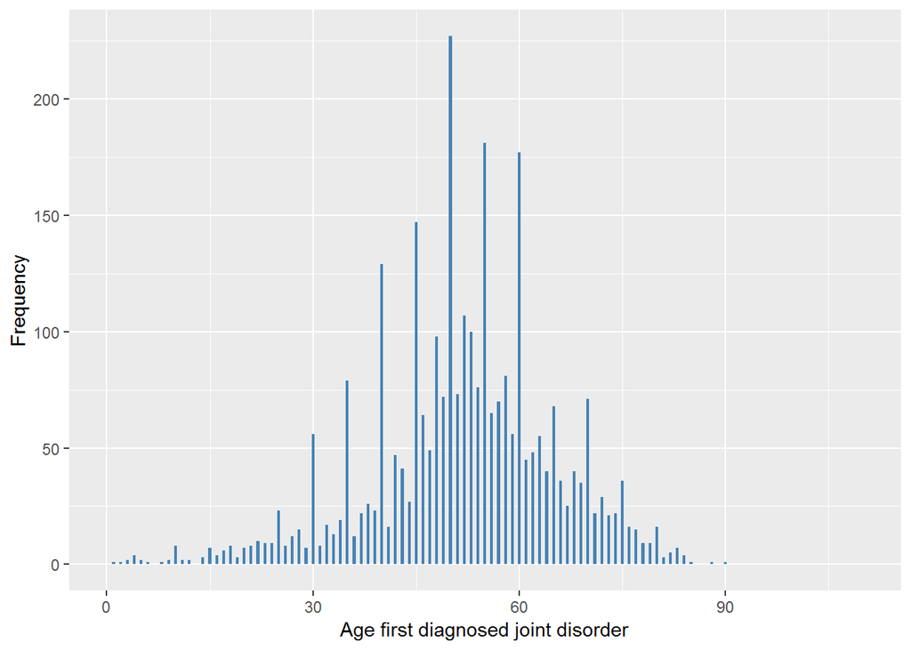

#### 2.1.4.4 Validation

|  | hedibar==0->0 | hedibar==1->1 | hedibar==-9->997 | hedibar==-8->998 |
| --- | --- | --- | --- | --- |
| BeforeH | 6941 | 4096 | 5 | 8 |
| AfterH | 6941 | 4096 | 5 | 8 |

### 2.1.5 Wave 5

#### 2.1.5.1 Study-specific variable description

| **Name** | `hedibar` | `heagf` |
| --- | --- | --- |
| **Label** | `Chronic: arthritis diagnosis newly reported` | `Age first told had arthritis` |
| **Table name** | `wave_5_elsa_data_v4` | `wave_5_elsa_data_v4` |
| **Categories** | `1 = Mentioned` `0 = Not mentioned` | `continuous` |
| **Missings** | `-9 = Refusal` `-8 = Don't know` `-1 = Not applicable` | `-9 = Refusal` `-8 = Don't know` `-1 = Not applicable` |
| **Description** |  |  |

hedibar

| Sample size | Missing values |
| --- | --- |
| 10274 | 15 |

Category

|  | 0 | 1 |
| --- | --- | --- |
| Frequency | 9667.00 | 592.00 |
| Percentage | 94.09 | 5.76 |

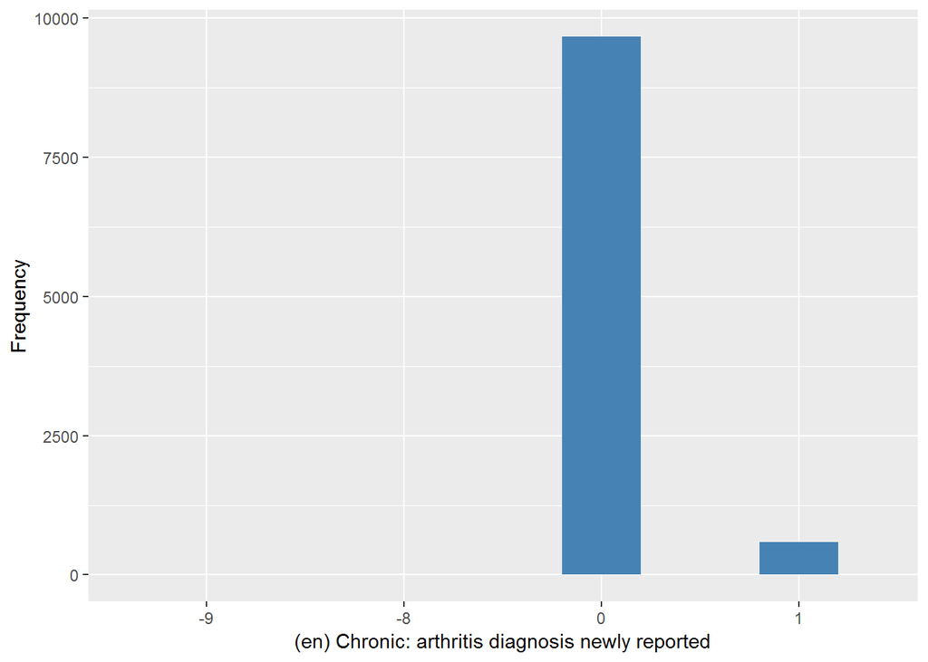

heagf

| Sample size | Missing values |
| --- | --- |
| 10274 | 10191 |

Summary

| Min. | 1st Qu. | Median | Mean | 3rd Qu. | Max. |
| --- | --- | --- | --- | --- | --- |
| 12 | 50 | 55 | 55.93 | 67 | 82 |

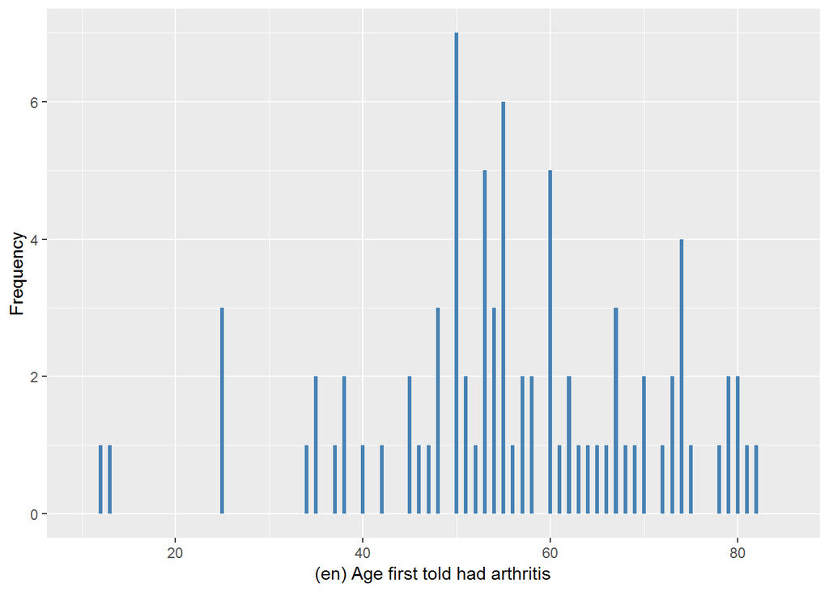

#### 2.1.5.2 Harmonisation algorithm

To compute `h_joint_disorders` from the study-specific variable it has to be recoded as follows:

- `h_joint_disorders previous == 1 or hedibar == 1 into 1`
- `h_joint_disorders previous == 0 and hedibar == 0 into 0`
- `hedibar == -9 into 997`
- `hedibar == -8 into 998`
- `otherwise into 999`

To compute `h_joint_disorders_age` from the study-specific variable it has to be recoded as follows:

- `if h_joint_disorders == 1, h_joint_disorders_age = heagf`
- `if h_joint_disorders == 0, h_joint_disorders_age = 996`
- `-1 into 996`
- `-8 into 998`
- `otherwise, h_joint_disorders_age = 999`

**R script:**

```r
ELSA_w5 <- left_join(ELSA_w5, ELSA_ds, by = "id")

# Categorical variable harmonization
ELSA_ds_w5 <- tibble(id = ELSA_w5$id)
ELSA_ds_w5$h_joint_disorders <- rep(999, length(ELSA_w5$id))
ELSA_ds_w5$h_joint_disorders[which((ELSA_w5$h_joint_disorders != 1 | is.na(ELSA_w5$h_joint_disorders)) &
    (ELSA_w5$hedibar == 0))] <- 0
ELSA_ds_w5$h_joint_disorders[which(ELSA_w5$h_joint_disorders == 1 | (ELSA_w5$hedibar ==
    1))] <- 1
ELSA_ds_w5$h_joint_disorders[which((ELSA_w5$h_joint_disorders != 1 | is.na(ELSA_w5$h_joint_disorders)) &
    ELSA_w5$hedibar == -9)] <- 997
ELSA_ds_w5$h_joint_disorders[which((ELSA_w5$h_joint_disorders != 1 | is.na(ELSA_w5$h_joint_disorders)) &
    ELSA_w5$hedibar == -8)] <- 998

# Continuous variable harmonization
ELSA_ds_w5$h_joint_disorders_age <- rep(999, length(ELSA_w5$id))
ELSA_ds_w5$h_joint_disorders_age[which(ELSA_ds_w5$h_joint_disorders == 0)] <- 996
ELSA_ds_w5$h_joint_disorders_age[which(ELSA_ds_w5$h_joint_disorders == 1)] <- car::recode(ELSA_w5$heagf[which(ELSA_ds_w5$h_joint_disorders ==
    1)], "-1=996;-2=991;-8=998;-9=997")
ELSA_ds_w5$h_joint_disorders_age[which(ELSA_ds_w5$h_joint_disorders == 1 & !is.na(ELSA_w5$h_joint_disorders_age) &
    !ELSA_w5$h_joint_disorders_age %in% miss_values_vector)] <- ELSA_w5$h_joint_disorders_age[which(ELSA_ds_w5$h_joint_disorders ==
    1 & !is.na(ELSA_w5$h_joint_disorders_age) & !ELSA_w5$h_joint_disorders_age %in%
    miss_values_vector)]

# Update of global table
assign_merge <- function(endtib, sttib, log_vec = c(T), col_end_index = NULL,
    col_st_index = NULL) {
    newtib <- full_join(endtib, sttib, by = "id")
    row.names(newtib) <- newtib$id
    newtib[log_vec, col_end_index] <- newtib[log_vec, col_st_index]
    id_ind <- match("id", names(newtib))
    newtib <- newtib[, c(id_ind, col_end_index)]
    names(newtib)[2] <- "x"
    newtib$x <- car::recode(newtib$x, "NA=999")
    names(newtib)[2] <- names(endtib)[col_end_index]
    newtib
}
ELSA_ds_prov <- ELSA_ds[, c(1, 2)]
ELSA_ds_prov <- assign_merge(ELSA_ds_prov, ELSA_ds_w5, log_vec = ELSA_ds_w5$id,
    col_end_index = 2, col_st_index = 3)
ELSA_ds_aux <- ELSA_ds[, c(1, 3)]
ELSA_ds_aux <- assign_merge(ELSA_ds_aux, ELSA_ds_w5, log_vec = ELSA_ds_w5$id[which(ELSA_ds_w5$h_joint_disorders !=
    999)], col_end_index = 2, col_st_index = 4)
ELSA_ds <- ELSA_ds_prov
ELSA_ds$h_joint_disorders_age <- ELSA_ds_aux$h_joint_disorders_age
rm(ELSA_ds_prov)
rm(ELSA_ds_aux)
```

#### 2.1.5.3 Statistics of the new harmonized variable

History of arthritis, rheumatism or osteoarthritis

| Sample size | Missing values |
| --- | --- |
| 10274 | 10 |

Category

|  | 0 | 1 |
| --- | --- | --- |
| Frequency | 6095.00 | 4169.00 |
| Percentage | 59.32 | 40.58 |

Type of missing

|  | 991 | 992 | 993 | 994 | 995 | 996 | 997 | 998 | 999 | NA |
| --- | --- | --- | --- | --- | --- | --- | --- | --- | --- | --- |
| Frequency | 0 | 0 | 0 | 0 | 0 | 0 | 3.00 | 7.00 | 0 | 0 |
| Percentage | 0 | 0 | 0 | 0 | 0 | 0 | 0.03 | 0.07 | 0 | 0 |

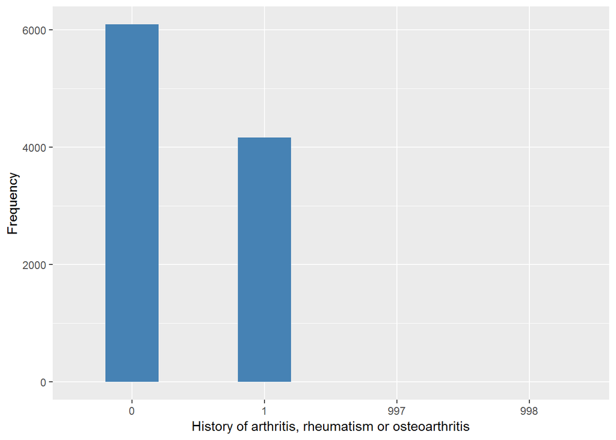

Age first diagnosed joint disorder

| Sample size | Missing values |
| --- | --- |
| 10274 | 7473 |

Values

|  | No-missings | 991 | 992 | 993 | 994 | 995 | 996 | 997 | 998 | 999 | NA |
| --- | --- | --- | --- | --- | --- | --- | --- | --- | --- | --- | --- |
| Frequency | 2801.00 | 0 | 0 | 0 | 0 | 0 | 7463.00 | 0 | 0 | 10.0 | 0 |
| Percentage | 27.26 | 0 | 0 | 0 | 0 | 0 | 72.64 | 0 | 0 | 0.1 | 0 |

Summary

| Min. | 1st Qu. | Median | Mean | 3rd Qu. | Max. |
| --- | --- | --- | --- | --- | --- |
| 0 | 45 | 52 | 51.32 | 60 | 88 |

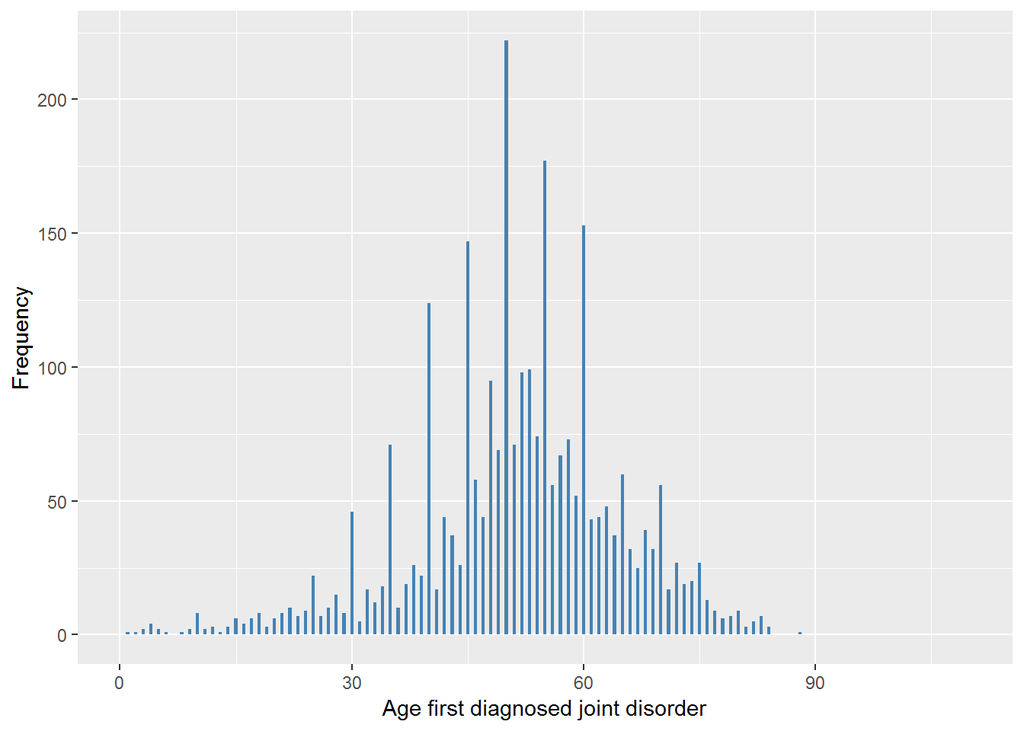

#### 2.1.5.4 Validation

|  | hedibar==0->0 | hedibar==1->1 | hedibar==-9->997 | hedibar==-8->998 |
| --- | --- | --- | --- | --- |
| BeforeH | 6095 | 4169 | 3 | 7 |
| AfterH | 6095 | 4169 | 3 | 7 |

### 2.1.6 Wave 6

#### 2.1.6.1 Study-specific variable description

| **Name** | `hedibar` | `HeAgf` |
| --- | --- | --- |
| **Label** | `Chronic: arthritis diagnosis newly reported` | `Age first told had arthritis` |
| **Table name** | `wave_6_elsa_data_v2` | `wave_6_elsa_data_v2` |
| **Categories** | `1 = Mentioned` `0 = Not mentioned` | `continuous` |
| **Missings** | `-9 = Refusal` `-8 = Don't know` `-1 = Not applicable` | `-9 = Refusal` `-8 = Don't know` `-1 = Not applicable` |
| **Description** |  |  |

hedibar

| Sample size | Missing values |
| --- | --- |
| 10601 | 8 |

Category

|  | 0 | 1 |
| --- | --- | --- |
| Frequency | 9879.00 | 714.00 |
| Percentage | 93.19 | 6.74 |

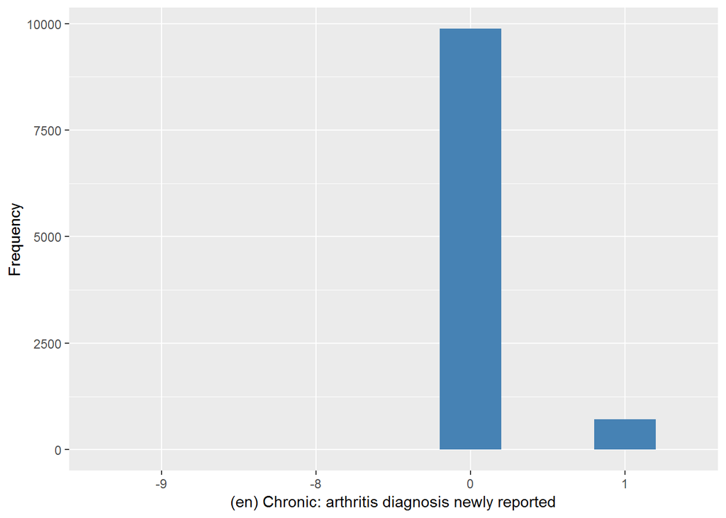

HeAgf

| Sample size | Missing values |
| --- | --- |
| 10601 | 10355 |

Summary

| Min. | 1st Qu. | Median | Mean | 3rd Qu. | Max. |
| --- | --- | --- | --- | --- | --- |
| 11 | 42 | 48 | 47.13 | 52 | 80 |

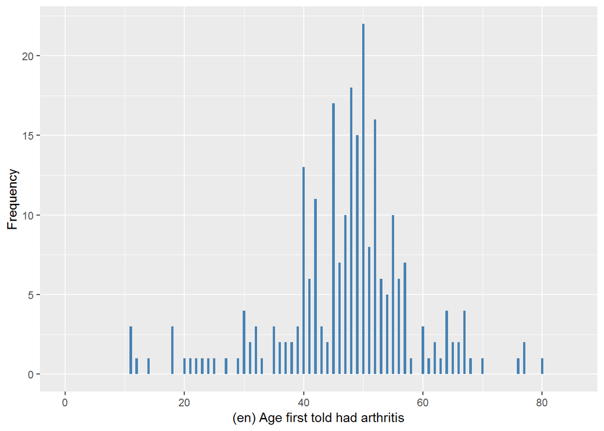

#### 2.1.6.2 Harmonisation algorithm

To compute `h_joint_disorders` from the study-specific variable it has to be recoded as follows:

- `h_joint_disorders previous == 1 or hedibar == 1 into 1`
- `h_joint_disorders previous == 0 and hedibar == 0 into 0`
- `hedibar == -9 into 997`
- `hedibar == -8 into 998`
- `otherwise into 999`

To compute `h_joint_disorders_age` from the study-specific variable it has to be recoded as follows:

- `if h_joint_disorders == 1, h_joint_disorders_age = HeAgf`
- `if h_joint_disorders == 0, h_joint_disorders_age = 996`
- `-1 into 996`
- `-8 into 998`
- `otherwise, h_joint_disorders_age = 999`

**R script:**

```r
ELSA_w6 <- left_join(ELSA_w6, ELSA_ds, by = "id")

# Categorical variable harmonization
ELSA_ds_w6 <- tibble(id = ELSA_w6$id)
ELSA_ds_w6$h_joint_disorders <- rep(999, length(ELSA_w6$id))
ELSA_ds_w6$h_joint_disorders[which((ELSA_w6$h_joint_disorders != 1 | is.na(ELSA_w6$h_joint_disorders)) &
    (ELSA_w6$hedibar == 0))] <- 0
ELSA_ds_w6$h_joint_disorders[which(ELSA_w6$h_joint_disorders == 1 | (ELSA_w6$hedibar ==
    1))] <- 1
ELSA_ds_w6$h_joint_disorders[which((ELSA_w6$h_joint_disorders != 1 | is.na(ELSA_w6$h_joint_disorders)) &
    ELSA_w6$hedibar == -9)] <- 997
ELSA_ds_w6$h_joint_disorders[which((ELSA_w6$h_joint_disorders != 1 | is.na(ELSA_w6$h_joint_disorders)) &
    ELSA_w6$hedibar == -8)] <- 998


# Continuous variable harmonization
ELSA_ds_w6$h_joint_disorders_age <- rep(999, length(ELSA_w6$id))
ELSA_ds_w6$h_joint_disorders_age[which(ELSA_ds_w6$h_joint_disorders == 0)] <- 996
ELSA_ds_w6$h_joint_disorders_age[which(ELSA_ds_w6$h_joint_disorders == 1)] <- car::recode(ELSA_w6$HeAgf[which(ELSA_ds_w6$h_joint_disorders ==
    1)], "-1=996;-2=991;-8=998;-9=997")
ELSA_ds_w6$h_joint_disorders_age[which(ELSA_ds_w6$h_joint_disorders == 1 & !is.na(ELSA_w6$h_joint_disorders_age) &
    !ELSA_w6$h_joint_disorders_age %in% miss_values_vector)] <- ELSA_w6$h_joint_disorders_age[which(ELSA_ds_w6$h_joint_disorders ==
    1 & !is.na(ELSA_w6$h_joint_disorders_age) & !ELSA_w6$h_joint_disorders_age %in%
    miss_values_vector)]

# Update of global table
assign_merge <- function(endtib, sttib, log_vec = c(T), col_end_index = NULL,
    col_st_index = NULL) {
    newtib <- full_join(endtib, sttib, by = "id")
    row.names(newtib) <- newtib$id
    newtib[log_vec, col_end_index] <- newtib[log_vec, col_st_index]
    id_ind <- match("id", names(newtib))
    newtib <- newtib[, c(id_ind, col_end_index)]
    names(newtib)[2] <- "x"
    newtib$x <- car::recode(newtib$x, "NA=999")
    names(newtib)[2] <- names(endtib)[col_end_index]
    newtib
}
ELSA_ds_prov <- ELSA_ds[, c(1, 2)]
ELSA_ds_prov <- assign_merge(ELSA_ds_prov, ELSA_ds_w6, log_vec = ELSA_ds_w6$id,
    col_end_index = 2, col_st_index = 3)
ELSA_ds_aux <- ELSA_ds[, c(1, 3)]
ELSA_ds_aux <- assign_merge(ELSA_ds_aux, ELSA_ds_w6, log_vec = ELSA_ds_w6$id[which(ELSA_ds_w6$h_joint_disorders !=
    999)], col_end_index = 2, col_st_index = 4)
ELSA_ds <- ELSA_ds_prov
ELSA_ds$h_joint_disorders_age <- ELSA_ds_aux$h_joint_disorders_age
rm(ELSA_ds_prov)
rm(ELSA_ds_aux)
```

#### 2.1.6.3 Statistics of the new harmonized variable

History of arthritis, rheumatism or osteoarthritis

| Sample size | Missing values |
| --- | --- |
| 10601 | 6 |

Category

|  | 0 | 1 |
| --- | --- | --- |
| Frequency | 6280.00 | 4315.0 |
| Percentage | 59.24 | 40.7 |

Type of missing

|  | 991 | 992 | 993 | 994 | 995 | 996 | 997 | 998 | 999 | NA |
| --- | --- | --- | --- | --- | --- | --- | --- | --- | --- | --- |
| Frequency | 0 | 0 | 0 | 0 | 0 | 0 | 4.00 | 2.00 | 0 | 0 |
| Percentage | 0 | 0 | 0 | 0 | 0 | 0 | 0.04 | 0.02 | 0 | 0 |

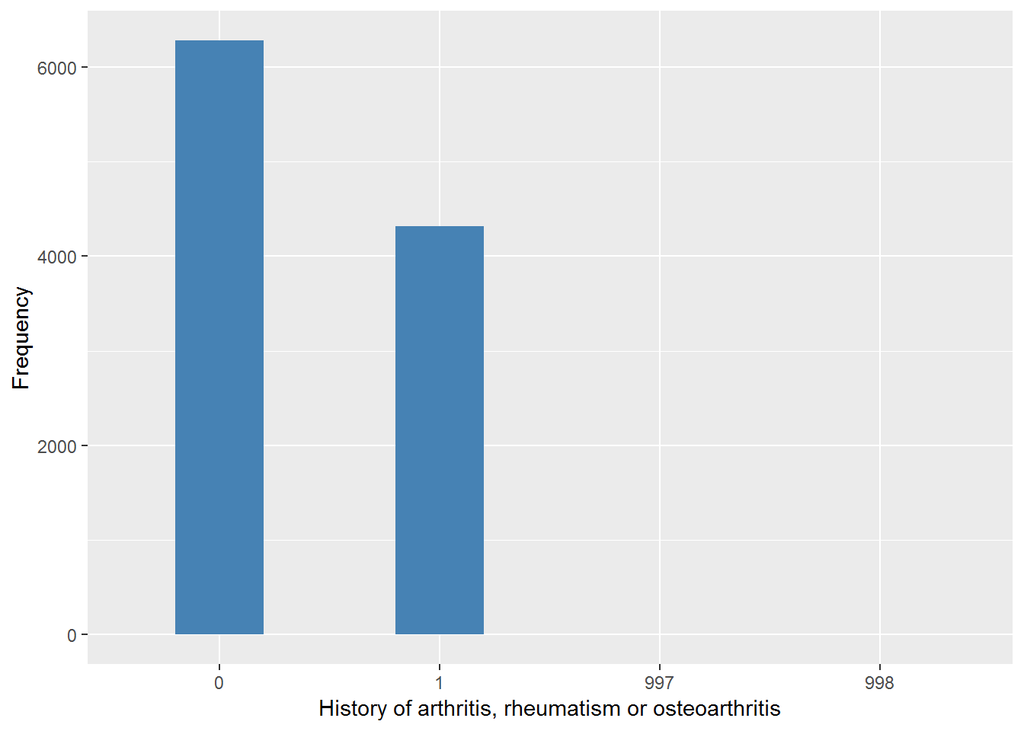

Age first diagnosed joint disorder

| Sample size | Missing values |
| --- | --- |
| 10601 | 7874 |

Values

|  | No-missings | 991 | 992 | 993 | 994 | 995 | 996 | 997 | 998 | 999 | NA |
| --- | --- | --- | --- | --- | --- | --- | --- | --- | --- | --- | --- |
| Frequency | 2727.00 | 0 | 0 | 0 | 0 | 0 | 7865.00 | 0 | 3.00 | 6.00 | 0 |
| Percentage | 25.72 | 0 | 0 | 0 | 0 | 0 | 74.19 | 0 | 0.03 | 0.06 | 0 |

Summary

| Min. | 1st Qu. | Median | Mean | 3rd Qu. | Max. |
| --- | --- | --- | --- | --- | --- |
| 0 | 45 | 51 | 50.4 | 58 | 88 |

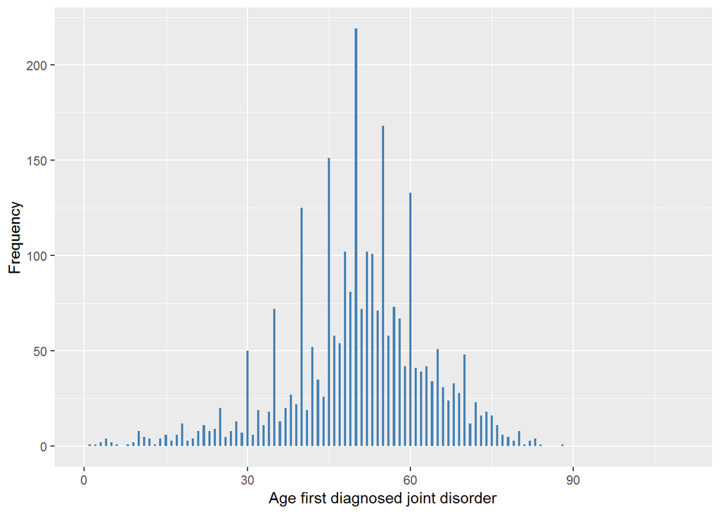

#### 2.1.6.4 Validation

|  | hedibar==0->0 | hedibar==1->1 | hedibar==-9->997 | hedibar==-8->998 |
| --- | --- | --- | --- | --- |
| BeforeH | 6280 | 4315 | 4 | 2 |
| AfterH | 6280 | 4315 | 4 | 2 |